# State-Level Happiness Analysis with Spatial Predictors

For this section, I wanted to see some other factors that might influence the happiness scores, including fiscal, educational, and geographic factors. As school resources, teacher and students’ relationship, and education itself are allocation important variable in developing students’ self esteem, I thought using education as a factor would be an interesting analysis. I used the fiscal data demonstrating states expenditures and the NAEP scores for 4th graders in the year 2022. By combining happiness scores with external datasets, the study investigates patterns in well-being and relationships with neighboring states.

```r
# Load libraries
library(tidyverse)
library(sf)
library(spdep)
library(viridis)
library(readxl)
library(rnaturalearth)
library(rnaturalearthdata)
library(corrplot)
library(readxl)
```

```r
# Load spatial and happiness datasets
us_states <- ne_states(country = "United States of America", returnclass = "sf")
happiness_state <- read_csv("../data/happiest_state_2022.csv", show_col_types = FALSE)

# Merge spatial and happiness data
merged_sf <- left_join(us_states, happiness_state, by = c("name" = "State"))
merged_sf <- merged_sf[!is.na(merged_sf$`Total Score`), ] # Remove rows with missing happiness scores


fiscal <- read_xlsx("../data/fiscal_predictors.xlsx")
outcomes <- read_xlsx("../data/outcome_data.xlsx")
dat2022 <- outcomes %>% filter(year == 2022)
performance_dat <- left_join(dat2022, fiscal, by = c('jurisdiction' = 'STABR', 'year' = 'TargetYear'))

merged_sf <- left_join(merged_sf, performance_dat, by = c("name" = "jurisLabel"))
merged_sf <- st_transform(merged_sf, crs = 3857)
```

### Visualizations

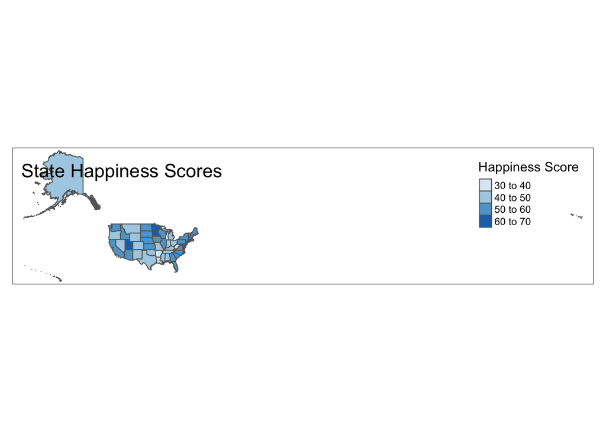

```r
library(tmap)

tm_shape(merged_sf) +
  tm_polygons("Total Score", palette = "Blues", title = "Happiness Score") +
  tm_layout(title = "State Happiness Scores")
```

This thematic map illustrates variations in happiness across states. Higher scores are concentrated in states like Hawaii, Maryland, and New Jersey, while lower scores are found in Louisiana and Arkansas.

### Spatial Autocorrelation

```r
library(spdep)

# Spatial neighbors and weights
neighbors <- poly2nb(merged_sf, queen = TRUE)
weights <- nb2listw(neighbors, style = "W", zero.policy = TRUE)

# Moran's I
morans <- moran.test(merged_sf$`Total Score`, weights, zero.policy = TRUE)
print(morans)
```

```
    Moran I test under randomisation

data:  merged_sf$`Total Score`
weights: weights
n reduced by no-neighbour observations

Moran I statistic standard deviate = 3.0626, p-value = 0.001097
alternative hypothesis: greater
sample estimates:
Moran I statistic       Expectation          Variance
      0.280211570      -0.021276596       0.009691088
```

Moran’s I was used to test for spatial autocorrelation in happiness scores. The global Moran’s I is 0.280 with a p-value of 0.001. This indicates significant clustering of happiness scores, with geographically close states tending to share similar levels of happiness.

### Predictors and Bivariate Relationships

```r
# Spatial lag of happiness scores
lagged_happiness <- lag.listw(weights, merged_sf$`Total Score`)

# Moran's I for math scores against lagged happiness scores
morans_bivariate <- lm.morantest(lm(math ~ lagged_happiness, data = merged_sf), weights)
print(morans_bivariate)
```

```
    Global Moran I for regression residuals

data:
model: lm(formula = math ~ lagged_happiness, data = merged_sf)
weights: weights

Moran I statistic standard deviate = 1.1903, p-value = 0.117
alternative hypothesis: greater
sample estimates:
Observed Moran I      Expectation         Variance
     0.094172376     -0.023891864      0.009838047
```

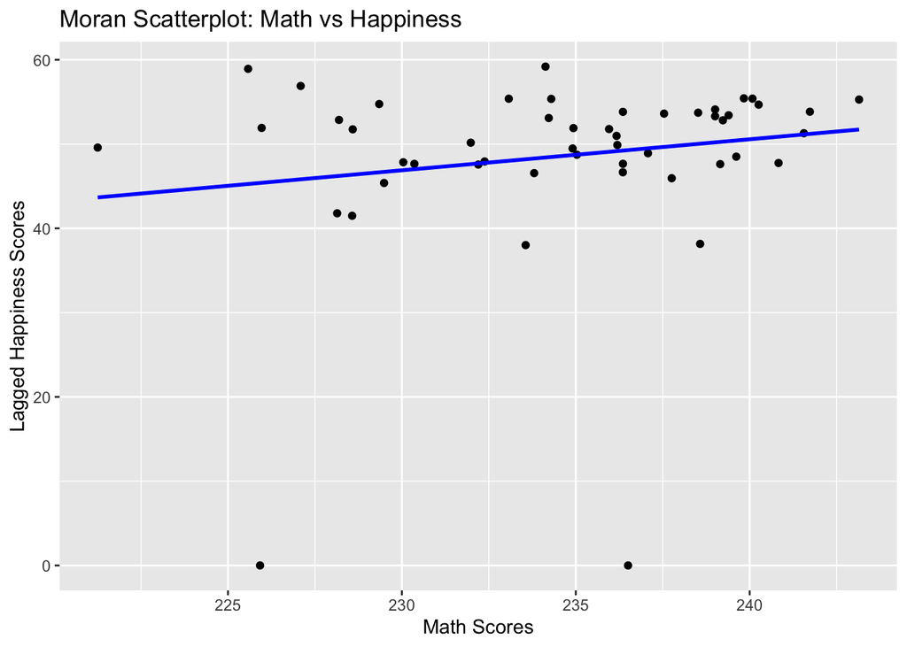

```r
library(ggplot2)

# Scatterplot
ggplot(data = merged_sf, aes(x = math, y = lagged_happiness)) +
  geom_point() +
  geom_smooth(method = "lm", se = FALSE, color = "blue") +
  labs(x = "Math Scores", y = "Lagged Happiness Scores", title = "Moran Scatterplot: Math vs Happiness")
```

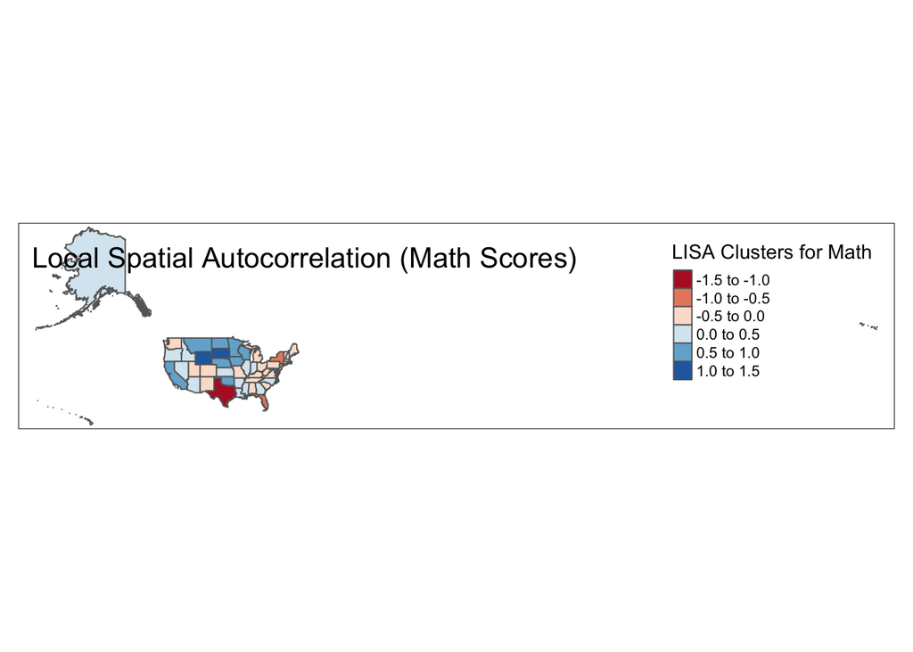

```r
# Local Moran's I for math scores
local_morans_math <- localmoran(merged_sf$math, weights)

# Add LISA results for math to the spatial dataset
merged_sf$lisa_math <- local_morans_math[, "Ii"]

# Map clusters for math scores
tm_shape(merged_sf) +
  tm_polygons("lisa_math", palette = "RdBu", title = "LISA Clusters for Math") +
  tm_layout(title = "Local Spatial Autocorrelation (Math Scores)")
```

```r
# Spatial lag of happiness scores
lagged_happiness <- lag.listw(weights, merged_sf$`Total Score`)

# Moran's I for reading scores against lagged happiness scores
morans_bivariate <- lm.morantest(lm(reading ~ lagged_happiness, data = merged_sf), weights)
print(morans_bivariate)
```

```
    Global Moran I for regression residuals

data:
model: lm(formula = reading ~ lagged_happiness, data = merged_sf)
weights: weights

Moran I statistic standard deviate = 0.69608, p-value = 0.2432
alternative hypothesis: greater
sample estimates:
Observed Moran I      Expectation         Variance
     0.045149968     -0.023891864      0.009838047
```

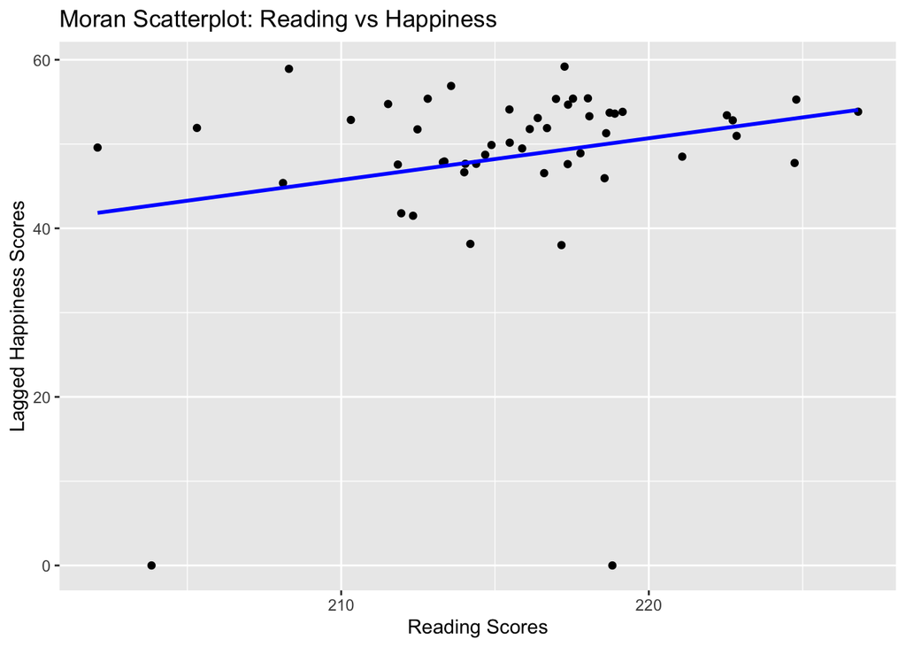

```r
library(ggplot2)

# Scatterplot
ggplot(data = merged_sf, aes(x = reading, y = lagged_happiness)) +
  geom_point() +
  geom_smooth(method = "lm", se = FALSE, color = "blue") +
  labs(x = "Reading Scores", y = "Lagged Happiness Scores", title = "Moran Scatterplot: Reading vs Happiness")
```

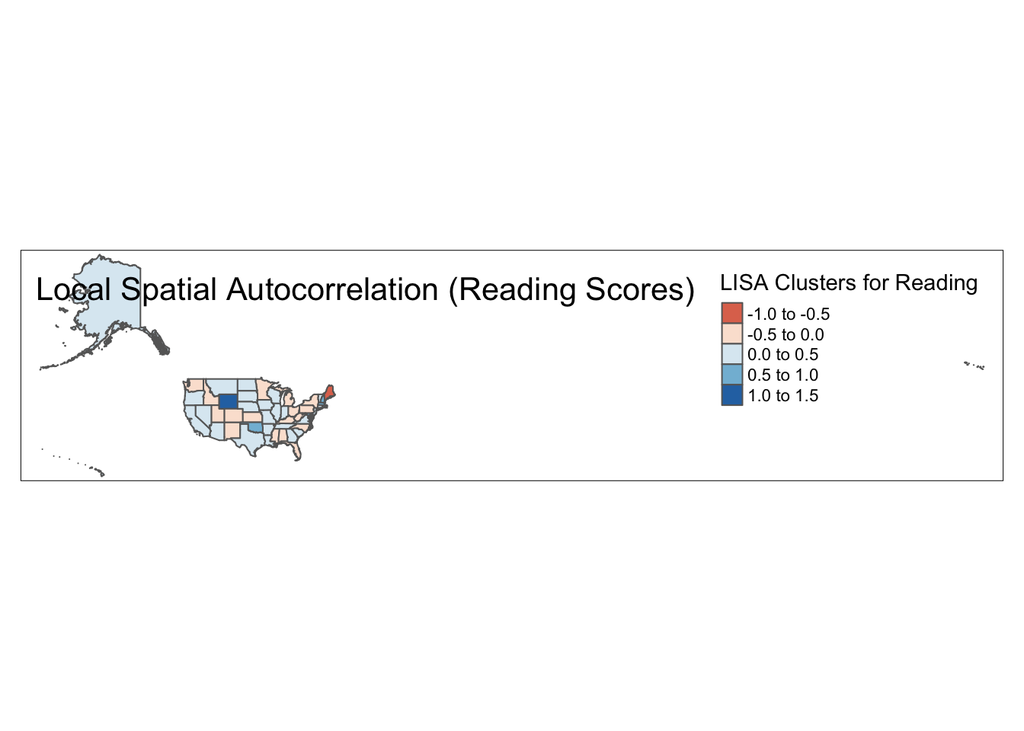

```r
# Local Moran's I for reading scores
local_morans_reading <- localmoran(merged_sf$reading, weights)

# Add LISA results for reading to the spatial dataset
merged_sf$lisa_reading <- local_morans_reading[, "Ii"]

# Map clusters for reading scores
tm_shape(merged_sf) +
  tm_polygons("lisa_reading", palette = "RdBu", title = "LISA Clusters for Reading") +
  tm_layout(title = "Local Spatial Autocorrelation (Reading Scores)")
```

```r
# Spatial lag of happiness scores
lagged_happiness <- lag.listw(weights, merged_sf$`Total Score`)

# Moran's I for expenditure on education against lagged happiness scores
morans_bivariate <- lm.morantest(lm(TE11 ~ lagged_happiness, data = merged_sf), weights)
print(morans_bivariate)
```

```
    Global Moran I for regression residuals

data:
model: lm(formula = TE11 ~ lagged_happiness, data = merged_sf)
weights: weights

Moran I statistic standard deviate = 0.32475, p-value = 0.3727
alternative hypothesis: greater
sample estimates:
Observed Moran I      Expectation         Variance
     0.008319333     -0.023891864      0.009838047
```

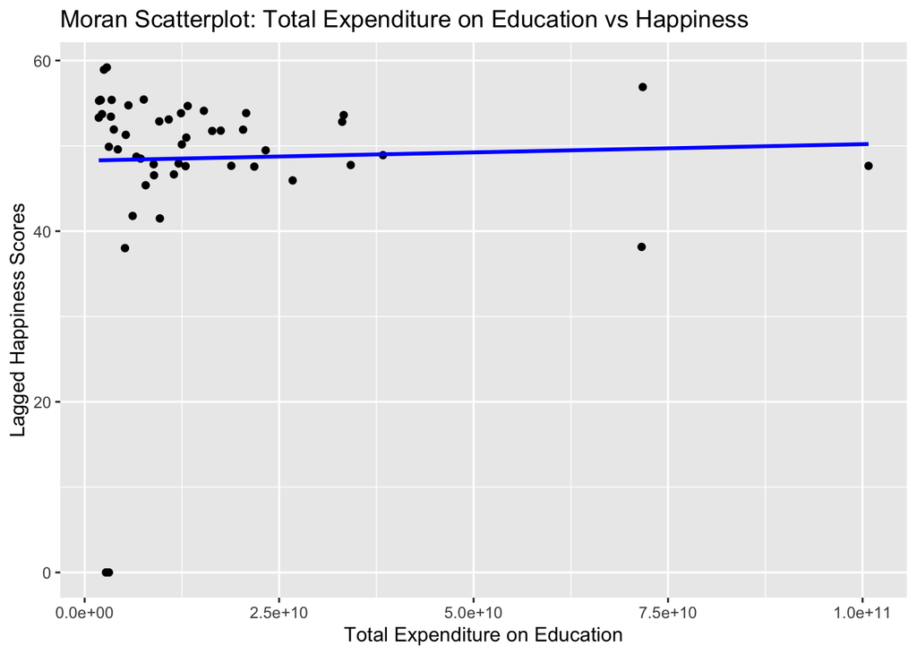

```r
library(ggplot2)

# Scatterplot
ggplot(data = merged_sf, aes(x = TE11, y = lagged_happiness)) +
  geom_point() +
  geom_smooth(method = "lm", se = FALSE, color = "blue") +
  labs(x = "Total Expenditure on Education", y = "Lagged Happiness Scores", title = "Moran Scatterplot: Total Expenditure on Education vs Happiness")
```

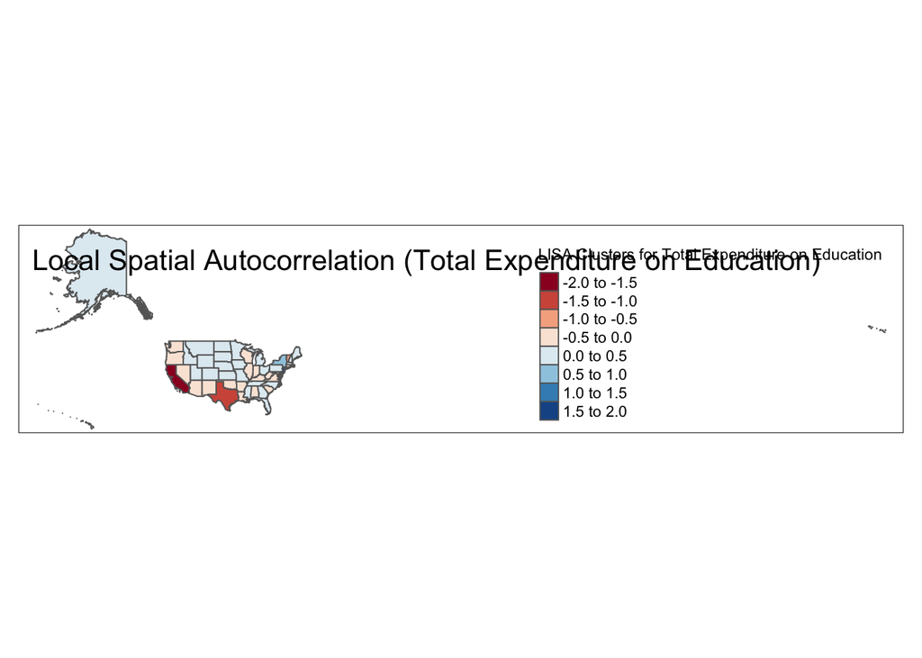

```r
# Local Moran's I for expenditure on education
local_morans_total_exp <- localmoran(merged_sf$TE11, weights)

# Add LISA results for math to the spatial dataset
merged_sf$lisa_total_exp <- local_morans_total_exp[, "Ii"]

# Map clusters for total expenditure on education
tm_shape(merged_sf) +
  tm_polygons("lisa_total_exp", palette = "RdBu", title = "LISA Clusters for Total Expenditure on Education") +
  tm_layout(title = "Local Spatial Autocorrelation (Total Expenditure on Education)")
```